# Payment Date Prediction

### Generate a new column "avgdelay" from the existing columns

- Note - You are expected to make a new column "avgdelay" by grouping "name_customer" column with reapect to mean of the "Delay" column.
- This new column "avg_delay" is meant to store "customer_name" wise delay
- groupby('name_customer')['Delay'].mean(numeric_only=False)
- Display the new "avg_delay" column

```python
avgdelay=maindata.groupby('name_customer')['delay'].mean(numeric_only=False)
```

You need to add the "avg_delay" column with the maindata, mapped with "name_customer" column

- Note - You need to use map function to map the avgdelay with respect to "name_customer" column

```python
maindata['avgdelay']=maindata['name_customer'].map(avgdelay)
```

### Observe that the "avg_delay" column is in days format. You need to change the format into seconds

```python
#maindata['avgdelay']=maindata['avgdelay'].dt.total_seconds()
maindata["avgdelay"] = maindata["avgdelay"] * 86400
maindata.avgdelay = maindata.avgdelay.round(2)
```

### Display the maindata dataframe

```python
maindata
```

|  | business_code | cust_number | name_customer | clear_date | buisness_year | doc_id | posting_date | due_in_date | baseline_create_date | cust_payment_terms | converted_usd | delay | avgdelay |
| --- | --- | --- | --- | --- | --- | --- | --- | --- | --- | --- | --- | --- | --- |
| 49999 | U001 | 0200020431 | DEC corp | 2019-01-15 | 2019.0 | 1.928576e+09 | 2019-01-05 | 2019-01-24 | 2019-01-01 | NAM4 | 1790.30 | -9 | -332307.69 |
| 42482 | U001 | 0200772670 | ASSOCIAT corporation | 2019-04-23 | 2019.0 | 1.929116e+09 | 2019-04-09 | 2019-04-24 | 2019-04-09 | NAU5 | 6790.77 | -1 | 99785.92 |
| 24985 | U001 | 0200762301 | C&S WH llc | 2019-04-26 | 2019.0 | 1.929120e+09 | 2019-04-12 | 2019-04-27 | 2019-04-12 | NAC6 | 95298.16 | -1 | 8000.00 |
| 24984 | U001 | 0200769623 | WAL-MAR llc | 2019-09-11 | 2019.0 | 1.929817e+09 | 2019-09-01 | 2019-09-16 | 2019-09-01 | NAH4 | 22480.23 | -5 | -226186.22 |
| 42483 | U001 | 0200769623 | WAL-MAR co | 2019-11-18 | 2019.0 | 1.930100e+09 | 2019-11-06 | 2019-11-21 | 2019-11-06 | NAH4 | 25844.81 | -3 | -212234.38 |
| ... | ... | ... | ... | ... | ... | ... | ... | ... | ... | ... | ... | ... | ... |
| 25690 | U001 | 0200769623 | WAL-MAR co | 2020-02-14 | 2020.0 | 1.930470e+09 | 2020-02-04 | 2020-02-19 | 2020-02-04 | NAH4 | 23129.59 | -5 | -212234.38 |
| 25663 | U001 | 0200762301 | C&S WH systems | 2020-01-27 | 2020.0 | 1.930378e+09 | 2020-01-10 | 2020-01-25 | 2020-01-10 | NAC6 | 14880.43 | 2 | -113958.62 |
| 25655 | U001 | 0200353024 | DECA systems | 2020-01-27 | 2020.0 | 1.930436e+09 | 2020-01-24 | 2020-01-26 | 2020-01-16 | NAM2 | 3766.19 | 1 | -388135.38 |
| 25647 | U001 | 0200759878 | SA llc | 2020-02-20 | 2020.0 | 1.930475e+09 | 2020-02-05 | 2020-02-20 | 2020-02-05 | NAH4 | 97921.91 | 0 | 13455.74 |
| 25638 | U001 | 0200772670 | ASSOCIAT foundation | 2020-03-09 | 2020.0 | 1.930565e+09 | 2020-02-24 | 2020-03-10 | 2020-02-24 | NAU5 | 18739.13 | -1 | 83895.65 |

38325 rows × 13 columns

### Since you have created the "avg_delay" column from "Delay" and "clear_date" column, there is no need of these two columns anymore

- You are expected to drop "Delay" and "clear_date" columns from maindata dataframe

```python
maindata=maindata.drop(['delay','clear_date'],axis=1)
```

```python
maindata.head()
```

|  | business_code | cust_number | name_customer | buisness_year | doc_id | posting_date | due_in_date | baseline_create_date | cust_payment_terms | converted_usd | avgdelay |
| --- | --- | --- | --- | --- | --- | --- | --- | --- | --- | --- | --- |
| 49999 | U001 | 0200020431 | DEC corp | 2019.0 | 1.928576e+09 | 2019-01-05 | 2019-01-24 | 2019-01-01 | NAM4 | 1790.30 | -332307.69 |
| 42482 | U001 | 0200772670 | ASSOCIAT corporation | 2019.0 | 1.929116e+09 | 2019-04-09 | 2019-04-24 | 2019-04-09 | NAU5 | 6790.77 | 99785.92 |
| 24985 | U001 | 0200762301 | C&S WH llc | 2019.0 | 1.929120e+09 | 2019-04-12 | 2019-04-27 | 2019-04-12 | NAC6 | 95298.16 | 8000.00 |
| 24984 | U001 | 0200769623 | WAL-MAR llc | 2019.0 | 1.929817e+09 | 2019-09-01 | 2019-09-16 | 2019-09-01 | NAH4 | 22480.23 | -226186.22 |
| 42483 | U001 | 0200769623 | WAL-MAR co | 2019.0 | 1.930100e+09 | 2019-11-06 | 2019-11-21 | 2019-11-06 | NAH4 | 25844.81 | -212234.38 |

# Splitting of Train and the Test Data

### You need to split the "maindata" columns into X and y dataframe

- Note - y should have the target column i.e. "avg_delay" and the other column should be in X
- X is going to hold the source fields and y will be going to hold the target fields

```python
y=maindata['avgdelay']
```

```python
x=maindata.drop('avgdelay',axis=1)
```

#### You are expected to split both the dataframes into train and test format in 60:40 ratio

- Note - The expected output should be in "X_train", "X_loc_test", "y_train", "y_loc_test" format

```python
x_train, x_loc_test, y_train, y_loc_test = train_test_split(x, y, test_size=0.4)
```

### Please check for the number of rows and columns of all the new dataframes (all 4)

```python
x_train.shape
```

```
(22995, 10)
```

```python
x_loc_test.shape
```

```
(15330, 10)
```

```python
y_train.shape
```

```
(22995,)
```

```python
y_loc_test.shape
```

```
(15330,)
```

### Now you are expected to split the "X_loc_test" and "y_loc_test" dataset into "Test" and "Validation" (as the names given below) dataframe with 50:50 format

- Note - The expected output should be in "X_val", "X_test", "y_val", "y_test" format

```python
x_val, x_test, y_val, y_test=train_test_split(x_loc_test, y_loc_test, test_size=0.5)
```

### Please check for the number of rows and columns of all the 4 dataframes

```python
x_val.shape
```

```
(7665, 10)
```

```python
x_test.shape
```

```
(7665, 10)
```

```python
y_test.shape
```

```
(7665,)
```

```python
y_val.shape
```

```
(7665,)
```

# Exploratory Data Analysis (EDA)

### Distribution Plot of the target variable (use the dataframe which contains the target field)

- Note - You are expected to make a distribution plot for the target variable

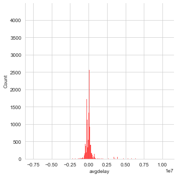

```python
# set the background style of the plot
sns.set_style('whitegrid')
sns.displot(maindata['avgdelay'], kde = False, color ='red')
#KDE stands for kernel density estimate , this function produces a less cluttered plot that is more interpretable
```

### You are expected to group the X_train dataset on 'name_customer' column with 'doc_id' in the x_train set

### Need to store the outcome into a new dataframe

- Note code given for groupby statement- X_train.groupby(by=['name_customer'], as_index=False)['doc_id'].count()

```python
x_train_new = x_train.groupby(by=['name_customer'], as_index=False)['doc_id'].count()
```

### You can make another distribution plot of the "doc_id" column from x_train

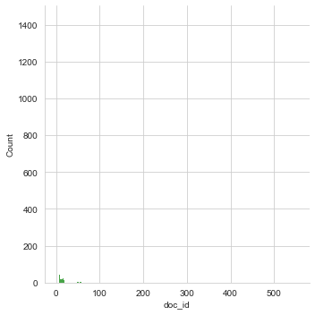

```python
#sns.set_style('whitegrid')
sns.displot(x_train_new["doc_id"], color = "g")
```

#### Create a Distribution plot only for business_year and a seperate distribution plot of "business_year" column along with the doc_id" column

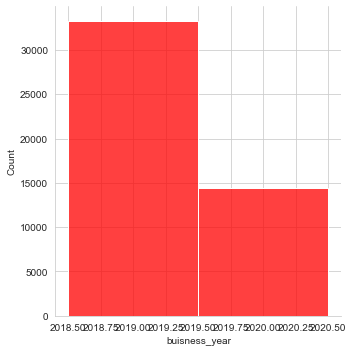

```python
sns.set_style('whitegrid')
sns.displot(df['buisness_year'],discrete=True, color ='red')
```

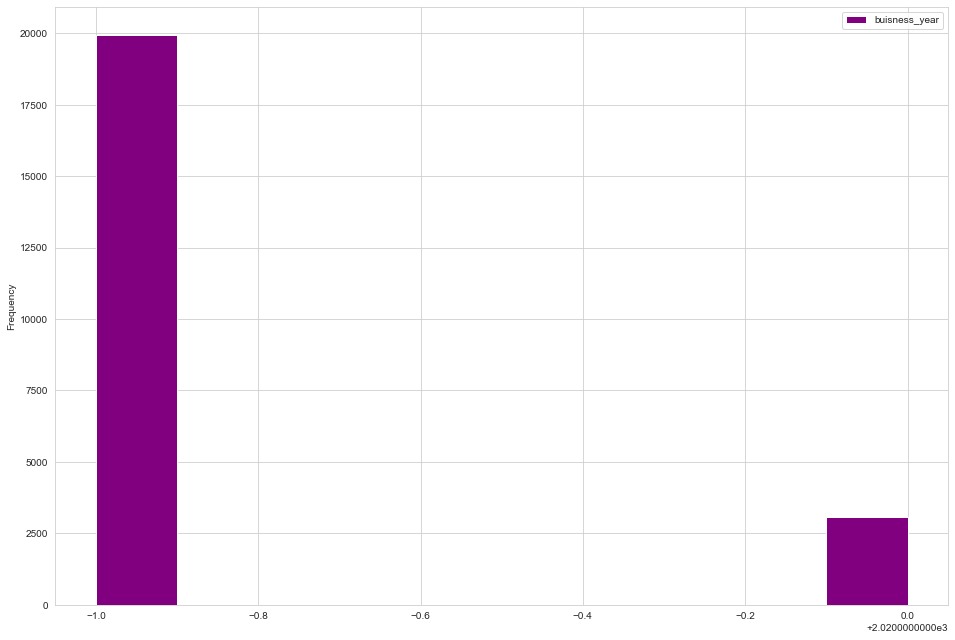

```python
#sns.set_style('whitegrid')
#sns.displot(df, x="buisness_year", y="doc_id", color='red')
x_train.plot(x = "doc_id", y = "buisness_year", kind = "hist", figsize = (16, 11), color = "purple")
```

# Feature Engineering

### Display and describe the X_train dataframe

```python
x_train.info()
```

```
<class 'pandas.core.frame.DataFrame'>
Int64Index: 22995 entries, 7223 to 22095
Data columns (total 10 columns):
 #   Column                Non-Null Count  Dtype
---  ------                --------------  -----
 0   business_code         22995 non-null  object
 1   cust_number           22995 non-null  object
 2   name_customer         22995 non-null  object
 3   buisness_year         22995 non-null  float64
 4   doc_id                22995 non-null  float64
 5   posting_date          22995 non-null  datetime64[ns]
 6   due_in_date           22995 non-null  datetime64[ns]
 7   baseline_create_date  22995 non-null  datetime64[ns]
 8   cust_payment_terms    22995 non-null  object
 9   converted_usd         22995 non-null  float64
dtypes: datetime64[ns](3), float64(3), object(4)
memory usage: 1.9+ MB
```

```python
x_train.describe()
```

|  | buisness_year | doc_id | converted_usd |
| --- | --- | --- | --- |
| count | 22995.000000 | 2.299500e+04 | 22995.000000 |
| mean | 2019.133333 | 2.014518e+09 | 30801.984038 |
| std | 0.339942 | 2.929893e+08 | 36659.007774 |
| min | 2019.000000 | 1.928502e+09 | 4.380000 |
| 25% | 2019.000000 | 1.929175e+09 | 4515.410000 |
| 50% | 2019.000000 | 1.929735e+09 | 16954.880000 |
| 75% | 2019.000000 | 1.930212e+09 | 45805.245000 |
| max | 2020.000000 | 9.500000e+09 | 668593.360000 |

#### The "business_code" column inside X_train, is a categorical column, so you need to perform Labelencoder on that particular column

- Note - call the Label Encoder from sklearn library and use the fit() function on "business_code" column
- Note - Please fill in the blanks (two) to complete this code

```python
from sklearn.preprocessing import LabelEncoder
business_coder = LabelEncoder()
business_coder.fit_transform(x_train['business_code'])
#Fit label encoder encodes and return encoded labels.
```

```
array([1, 1, 1, ..., 1, 0, 1])
```

#### You are expected to store the value into a new column i.e. "business_code_enc"

- Note - For Training set you are expected to use fit_trainsform()
- Note - For Test set you are expected to use the trainsform()
- Note - For Validation set you are expected to use the trainsform()
- Partial code is provided, please fill in the blanks

```python
x_train['business_code_enc'] = business_coder.fit_transform(x_train['business_code'])
```

```python
x_val['business_code_enc'] = business_coder.transform(x_val['business_code'])
x_test['business_code_enc'] = business_coder.transform(x_test['business_code'])
```

### Display "business_code" and "business_code_enc" together from X_train dataframe

```python
x_train[['business_code_enc','business_code']]
```

|  | business_code_enc | business_code |
| --- | --- | --- |
| 7223 | 1 | U001 |
| 47297 | 1 | U001 |
| 8452 | 1 | U001 |
| 1575 | 1 | U001 |
| 37584 | 1 | U001 |
| ... | ... | ... |
| 34942 | 1 | U001 |
| 19379 | 1 | U001 |
| 31722 | 1 | U001 |
| 441 | 0 | CA02 |
| 22095 | 1 | U001 |

22995 rows × 2 columns

#### Create a function called "custom" for dropping the columns 'business_code' from train, test and validation dataframe

- Note - Fill in the blank to complete the code

```python
def custom(col ,traindf = x_train,valdf = x_val,testdf = x_test):
    traindf.drop(col, axis =1,inplace=True)
    valdf.drop(col,axis=1 , inplace=True)
    testdf.drop(col,axis=1 , inplace=True)

    return traindf,valdf ,testdf
```

### Call the function by passing the column name which needed to be dropped from train, test and validation dataframes. Return updated dataframes to be stored in X_train ,X_val, X_test

- Note = Fill in the blank to complete the code

```python
x_train ,x_val, x_test = custom(['business_code'])
```

### Manually replacing str values with numbers, Here we are trying manually replace the customer numbers with some specific values like, 'CCCA' as 1, 'CCU' as 2 and so on. Also we are converting the datatype "cust_number" field to int type.

- We are doing it for all the three dataframes as shown below. This is fully completed code. No need to modify anything here

```python
x_train['cust_number'] = x_train['cust_number'].str.replace('CCCA',"1").str.replace('CCU',"2").str.replace('CC',"3").astype(int)
x_test['cust_number'] = x_test['cust_number'].str.replace('CCCA',"1").str.replace('CCU',"2").str.replace('CC',"3").astype(int)
x_val['cust_number'] = x_val['cust_number'].str.replace('CCCA',"1").str.replace('CCU',"2").str.replace('CC',"3").astype(int)
```

#### It differs from LabelEncoder by handling new classes and providing a value for it [Unknown]. Unknown will be added in fit and transform will take care of new item. It gives unknown class id.

#### This will fit the encoder for all the unique values and introduce unknown value

- Note - Keep this code as it is, we will be using this later on.

```python
#For encoding unseen labels
class EncoderExt(object):
    def __init__(self):
        self.label_encoder = LabelEncoder()
    def fit(self, data_list):
        self.label_encoder = self.label_encoder.fit(list(data_list) + ['Unknown'])
        self.classes_ = self.label_encoder.classes_
        return self
    def transform(self, data_list):
        new_data_list = list(data_list)
        for unique_item in np.unique(data_list):
            if unique_item not in self.label_encoder.classes_:
                new_data_list = ['Unknown' if x==unique_item else x for x in new_data_list]
        return self.label_encoder.transform(new_data_list)
```

### Use the user define Label Encoder function called "EncoderExt" for the "name_customer" column

- Note - Keep the code as it is, no need to change

```python
label_encoder = EncoderExt()
label_encoder.fit(x_train['name_customer'])
x_train['name_customer_enc']=label_encoder.transform(x_train['name_customer'])
x_val['name_customer_enc']=label_encoder.transform(x_val['name_customer'])
x_test['name_customer_enc']=label_encoder.transform(x_test['name_customer'])
```

### As we have created the a new column "name_customer_enc", so now drop "name_customer" column from all three dataframes

- Note - Keep the code as it is, no need to change

```python
x_train ,x_val, x_test = custom(['name_customer'])
#calling the function here that we created above to drop columns.
```

### Using Label Encoder for the "cust_payment_terms" column

- Note - Keep the code as it is, no need to change

```python
label_encoder1 = EncoderExt()
label_encoder1.fit(x_train['cust_payment_terms'])
x_train['cust_payment_terms_enc']=label_encoder1.transform(x_train['cust_payment_terms'])
x_val['cust_payment_terms_enc']=label_encoder1.transform(x_val['cust_payment_terms'])
x_test['cust_payment_terms_enc']=label_encoder1.transform(x_test['cust_payment_terms'])
```

```python
x_train ,x_val, x_test = custom(['cust_payment_terms'])
```

## Check the datatype of all the columns of Train, Test and Validation dataframes realted to X

- Note - You are expected yo use dtype

```python
x_train.dtypes
```

```
cust_number                        int32
buisness_year                    float64
doc_id                           float64
posting_date              datetime64[ns]
due_in_date               datetime64[ns]
baseline_create_date      datetime64[ns]
converted_usd                    float64
business_code_enc                  int32
name_customer_enc                  int32
cust_payment_terms_enc             int32
dtype: object
```

```python
x_test.dtypes
```

```
cust_number                        int32
buisness_year                    float64
doc_id                           float64
posting_date              datetime64[ns]
due_in_date               datetime64[ns]
baseline_create_date      datetime64[ns]
converted_usd                    float64
business_code_enc                  int32
name_customer_enc                  int32
cust_payment_terms_enc             int32
dtype: object
```

```python
x_val.dtypes
```

```
cust_number                        int32
buisness_year                    float64
doc_id                           float64
posting_date              datetime64[ns]
due_in_date               datetime64[ns]
baseline_create_date      datetime64[ns]
converted_usd                    float64
business_code_enc                  int32
name_customer_enc                  int32
cust_payment_terms_enc             int32
dtype: object
```

### From the above output you can notice their are multiple date columns with datetime format

### In order to pass it into our model, we need to convert it into float format

### You need to extract day, month and year from the "posting_date" column

1. Extract days from "posting_date" column and store it into a new column "day_of_postingdate" for train, test and validation dataset
2. Extract months from "posting_date" column and store it into a new column "month_of_postingdate" for train, test and validation dataset
3. Extract year from "posting_date" column and store it into a new column "year_of_postingdate" for train, test and validation dataset
- Note - You are supposed yo use
- dt.day
- dt.month
- dt.year

```python
x_train['day_of_postingdate'] = x_train['posting_date'].dt.day
x_train['month_of_postingdate'] = x_train['posting_date'].dt.month
x_train['year_of_postingdate'] = x_train['posting_date'].dt.year

x_val['day_of_postingdate'] = x_val['posting_date'].dt.day
x_val['month_of_postingdate'] = x_val['posting_date'].dt.month
x_val['year_of_postingdate'] = x_val['posting_date'].dt.year


x_test['day_of_postingdate'] = x_test['posting_date'].dt.day
x_test['month_of_postingdate'] = x_test['posting_date'].dt.month
x_test['year_of_postingdate'] = x_test['posting_date'].dt.year
```

### pass the "posting_date" column into the Custom function for train, test and validation dataset

```python
x_train ,x_val, x_test = custom(['posting_date'])
```

### You need to extract day, month and year from the "baseline_create_date" column

1. Extract days from "baseline_create_date" column and store it into a new column "day_of_createdate" for train, test and validation dataset
2. Extract months from "baseline_create_date" column and store it into a new column "month_of_createdate" for train, test and validation dataset
3. Extract year from "baseline_create_date" column and store it into a new column "year_of_createdate" for train, test and validation dataset
- Note - You are supposed yo use
- dt.day
- dt.month
- dt.year
- Note - Do as it is been shown in the previous two code boxes

### Extracting Day, Month, Year for 'baseline_create_date' column

```python
x_train['day_of_createdate'] = x_train['baseline_create_date'].dt.day
x_train['month_of_createdate'] = x_train['baseline_create_date'].dt.month
x_train['year_of_createdate'] = x_train['baseline_create_date'].dt.year

x_val['day_of_createdate'] = x_val['baseline_create_date'].dt.day
x_val['month_of_createdate'] = x_val['baseline_create_date'].dt.month
x_val['year_of_createdate'] = x_val['baseline_create_date'].dt.year

x_test['day_of_createdate'] = x_test['baseline_create_date'].dt.day
x_test['month_of_createdate'] = x_test['baseline_create_date'].dt.month
x_test['year_of_createdate'] = x_test['baseline_create_date'].dt.year
```

### pass the "baseline_create_date" column into the Custom function for train, test and validation dataset

```python
x_train ,x_val, x_test = custom(['baseline_create_date'])
#dropping the column by calling custom function.
```

### You need to extract day, month and year from the "due_in_date" column

1. Extract days from "due_in_date" column and store it into a new column "day_of_due" for train, test and validation dataset
2. Extract months from "due_in_date" column and store it into a new column "month_of_due" for train, test and validation dataset
3. Extract year from "due_in_date" column and store it into a new column "year_of_due" for train, test and validation dataset
- Note - You are supposed yo use
- dt.day
- dt.month
- dt.year
- Note - Do as it is been shown in the previous code

```python
x_train['day_of_duedate'] = x_train['due_in_date'].dt.day
x_train['month_of_duedate'] = x_train['due_in_date'].dt.month
x_train['year_of_duedate'] = x_train['due_in_date'].dt.year

x_val['day_of_due'] = x_val['due_in_date'].dt.day
x_val['month_of_due'] = x_val['due_in_date'].dt.month
x_val['year_of_due'] = x_val['due_in_date'].dt.year

x_test['day_of_due'] = x_test['due_in_date'].dt.day
x_test['month_of_due'] = x_test['due_in_date'].dt.month
x_test['year_of_due'] = x_test['due_in_date'].dt.year
```

pass the "due_in_date" column into the Custom function for train, test and validation dataset

```python
x_train ,x_val, x_test = custom(['due_in_date'])
#dropping column by calling custom function
```

### Check for the datatypes for train, test and validation set again

- Note - all the data type should be in either int64 or float64 format

```python
print(x_train.dtypes,"\n\n", x_test.dtypes, "\n\n", x_val.dtypes)
```

```
cust_number                 int32
buisness_year             float64
doc_id                    float64
converted_usd             float64
business_code_enc           int32
name_customer_enc           int32
cust_payment_terms_enc      int32
day_of_postingdate          int64
month_of_postingdate        int64
year_of_postingdate         int64
day_of_createdate           int64
month_of_createdate         int64
year_of_createdate          int64
day_of_duedate              int64
month_of_duedate            int64
year_of_duedate             int64
dtype: object

 cust_number                 int32
buisness_year             float64
doc_id                    float64
converted_usd             float64
business_code_enc           int32
name_customer_enc           int32
cust_payment_terms_enc      int32
day_of_postingdate          int64
month_of_postingdate        int64
year_of_postingdate         int64
day_of_createdate           int64
month_of_createdate         int64
year_of_createdate          int64
day_of_due                  int64
month_of_due                int64
year_of_due                 int64
dtype: object

 cust_number                 int32
buisness_year             float64
doc_id                    float64
converted_usd             float64
business_code_enc           int32
name_customer_enc           int32
cust_payment_terms_enc      int32
day_of_postingdate          int64
month_of_postingdate        int64
year_of_postingdate         int64
day_of_createdate           int64
month_of_createdate         int64
year_of_createdate          int64
day_of_due                  int64
month_of_due                int64
year_of_due                 int64
dtype: object
```

# Feature Selection

### Filter Method

- Calling the VarianceThreshold Function
- Note - Keep the code as it is, no need to change

```python
from sklearn.feature_selection import VarianceThreshold
constant_filter = VarianceThreshold(threshold=0)
constant_filter.fit(x_train)
len(x_train.columns[constant_filter.get_support()])
#variancethreshold- It removes all features whose variance doesn’t meet some threshold.
```

```
16
```

- Note - Keep the code as it is, no need to change

```python
#to get all the features that are not constant, we can use the get_support()
constant_columns = [column for column in x_train.columns
                    if column not in x_train.columns[constant_filter.get_support()]]
print(len(constant_columns))
```

```
0
```

- transpose the feature matrice
- print the number of duplicated features
- select the duplicated features columns names
- Note - Keep the code as it is, no need to change

```python
#The duplicated() method returns a Series with True and False values that describe which rows in the DataFrame are duplicated and not.
#here it returns index containing duplicated values.
xx_train_T = x_train.T
print(xx_train_T.duplicated().sum())
duplicated_columns = xx_train_T[xx_train_T.duplicated()].index.values
```

```
0
```

### Filtering depending upon correlation matrix value

- We have created a function called handling correlation which is going to return fields based on the correlation matrix value with a threshold of 0.8
- Note - Keep the code as it is, no need to change

```python
def handling_correlation(x_train,threshold=0.8):
    corr_features = set()
    corr_matrix = x_train.corr()
    for i in range(len(corr_matrix .columns)):
        for j in range(i):
            if abs(corr_matrix.iloc[i, j]) >threshold:
                colname = corr_matrix.columns[i]
                corr_features.add(colname)
    return list(corr_features)
```

- Note : Here we are trying to find out the relevant fields, from X_train
- Please fill in the blanks to call handling_correlation() function with a threshold value of 0.85

```python
train=x_train.copy()
handling_correlation(train.copy(),threshold=0.85)
```

```
['day_of_createdate',
 'month_of_duedate',
 'year_of_createdate',
 'month_of_createdate',
 'year_of_duedate',
 'year_of_postingdate']
```

### Heatmap for X_train

- Note - Keep the code as it is, no need to change

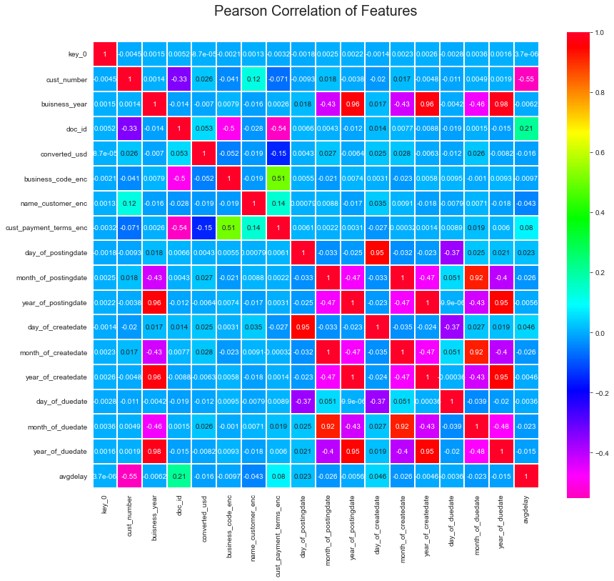

```python
colormap = plt.cm.RdBu
plt.figure(figsize=(14,12))
plt.title('Pearson Correlation of Features', y=1.05, size=20)
sns.heatmap(x_train.merge(y_train , on = x_train.index ).corr(),linewidths=0.1,vmax=1.0,
            square=True, cmap='gist_rainbow_r', linecolor='white', annot=True)
```

#### Calling variance threshold for threshold value = 0.8

- Note - Fill in the blanks to call the appropriate method

```python
from sklearn.feature_selection import VarianceThreshold
sel = VarianceThreshold(0.8)
sel.fit(x_train)
```

```
VarianceThreshold(threshold=0.8)
```

```python
sel.variances_
```

```
array([1.80956536e+15, 1.15555556e-01, 8.58389888e+16, 1.34382441e+09,
       2.89670119e-01, 1.04695542e+06, 1.18095580e+02, 7.56437415e+01,
       1.23356173e+01, 1.16125032e-01, 7.72655475e+01, 1.23483643e+01,
       1.16233828e-01, 7.64820698e+01, 1.21427664e+01, 1.18797525e-01])
```

### Important features columns are

- 'year_of_createdate'
- 'year_of_due'
- 'day_of_createdate'
- 'year_of_postingdate'
- 'month_of_due'
- 'month_of_createdate'

# Modelling

#### Now you need to compare with different machine learning models, and needs to find out the best predicted model

- Linear Regression
- Decision Tree Regression
- Random Forest Regression
- Support Vector Regression
- Extreme Gradient Boost Regression

### You need to make different blank list for different evaluation matrix

- MSE
- R2
- Algorithm

```python
MSE_Score = []
R2_Score = []
Algorithm = []
from sklearn.metrics import mean_squared_error
from sklearn.metrics import r2_score
```

### You need to start with the baseline model Linear Regression

- Step 1 : Call the Linear Regression from sklearn library
- Step 2 : make an object of Linear Regression
- Step 3 : fit the X_train and y_train dataframe into the object
- Step 4 : Predict the output by passing the X_test Dataset into predict function
- Note - Append the Algorithm name into the algorithm list for tracking purpose

```python
from sklearn.linear_model import LinearRegression
Algorithm.append('LinearRegression')
regressor = LinearRegression()
regressor.fit(x_train, y_train)
predicted= regressor.predict(x_test)
```

### Check for the

- Mean Square Error
- R Square Error

for y_test and predicted dataset and store those data inside respective list for comparison

```python
MSE_Score.append(mean_squared_error(y_test, predicted))
R2_Score.append(r2_score(y_test, predicted))
```

### Check the same for the Validation set also

```python
predict_test= regressor.predict(x_val)
mean_squared_error(y_val, predict_test, squared=False)
```

```
563483.3283273078
```

### Display The Comparison Lists

```python
for i in Algorithm, MSE_Score, R2_Score:
    print(i,end=',')
```

```
['LinearRegression'],[281661548017.245],[0.3236418512270096],
```

### You need to start with the baseline model Support Vector Regression

- Step 1 : Call the Support Vector Regressor from sklearn library
- Step 2 : make an object of SVR
- Step 3 : fit the X_train and y_train dataframe into the object
- Step 4 : Predict the output by passing the X_test Dataset into predict function
- Note - Append the Algorithm name into the algorithm list for tracking purpose

```python
from sklearn.svm import SVR
Algorithm.append('SupportVectorRegression')
regressor = SVR()
regressor.fit(x_train, y_train)
predicted= regressor.predict(x_test)
```

### Check for the

- Mean Square Error
- R Square Error

for "y_test" and "predicted" dataset and store those data inside respective list for comparison

```python
MSE_Score.append(mean_squared_error(y_test, predicted))
R2_Score.append(r2_score(y_test, predicted))
```

### Check the same for the Validation set also

```python
predict_test= regressor.predict(x_val)
mean_squared_error(y_val, predict_test, squared=False)
```

```
671134.362401591
```

### Display The Comparison Lists

```python
for i in Algorithm, MSE_Score, R2_Score:
    print(i,end=',')
```

```
['LinearRegression', 'SupportVectorRegression'],[281661548017.245, 419952414193.79083],[0.3236418512270096, -0.008438103945483943],
```

### Your next model would be Decision Tree Regression

- Step 1 : Call the Decision Tree Regressor from sklearn library
- Step 2 : make an object of Decision Tree
- Step 3 : fit the X_train and y_train dataframe into the object
- Step 4 : Predict the output by passing the X_test Dataset into predict function
- Note - Append the Algorithm name into the algorithm list for tracking purpose

```python
from sklearn.tree import DecisionTreeRegressor
Algorithm.append('DecisonTreeRegression')
regressor = DecisionTreeRegressor()
regressor.fit(x_train, y_train)
predicted= regressor.predict(x_test)
```

### Check for the

- Mean Square Error
- R Square Error

for y_test and predicted dataset and store those data inside respective list for comparison

```python
MSE_Score.append(mean_squared_error(y_test, predicted))
R2_Score.append(r2_score(y_test, predicted))
```

### Check the same for the Validation set also

```python
predict_test= regressor.predict(x_val)
mean_squared_error(y_val, predict_test, squared=False)
```

```
473304.6659003673
```

### Display The Comparison Lists

```python
for i in Algorithm, MSE_Score, R2_Score:
    print(i,end=',')
```

```
['LinearRegression', 'SupportVectorRegression', 'DecisonTreeRegression'],[281661548017.245, 419952414193.79083, 215895221137.1857],[0.3236418512270096, -0.008438103945483943, 0.48156752980587203],
```

### Your next model would be Random Forest Regression

- Step 1 : Call the Random Forest Regressor from sklearn library
- Step 2 : make an object of Random Forest
- Step 3 : fit the X_train and y_train dataframe into the object
- Step 4 : Predict the output by passing the X_test Dataset into predict function
- Note - Append the Algorithm name into the algorithm list for tracking purpose

```python
from sklearn.ensemble import RandomForestRegressor
Algorithm.append('RandomForestRegressor')
regressor =RandomForestRegressor()
regressor.fit(x_train, y_train)
predicted= regressor.predict(x_test)
```

### Check for the

- Mean Square Error
- R Square Error

for y_test and predicted dataset and store those data inside respective list for comparison

```python
MSE_Score.append(mean_squared_error(y_test, predicted))
R2_Score.append(r2_score(y_test, predicted))
```

### Check the same for the Validation set also

```python
predict_test= regressor.predict(x_val)
mean_squared_error(y_val, predict_test, squared=False)
```

```
395159.5386398983
```

### Display The Comparison Lists

```python
for i in Algorithm, MSE_Score, R2_Score:
    print(i,end=',')
```

```
['LinearRegression', 'SupportVectorRegression', 'DecisonTreeRegression', 'RandomForestRegressor'],[281661548017.245, 419952414193.79083, 215895221137.1857, 141992480232.49686],[0.3236418512270096, -0.008438103945483943, 0.48156752980587203, 0.6590313028320891],
```

### The last but not the least model would be XGBoost or Extreme Gradient Boost Regression

- Step 1 : Call the XGBoost Regressor from xgb library
- Step 2 : make an object of Xgboost
- Step 3 : fit the X_train and y_train dataframe into the object
- Step 4 : Predict the output by passing the X_test Dataset into predict function
- Note - Append the Algorithm name into the algorithm list for tracking purpose### Extreme Gradient Boost Regression
- Note - No need to change the code

```python
#pip install xgboost
```

```python
import xgboost as xgb
Algorithm.append('XGB Regressor')
regressor = xgb.XGBRegressor()
regressor.fit(x_train, y_train)
predicted = regressor.predict(x_test)
```

### Check for the

- Mean Square Error
- R Square Error

for y_test and predicted dataset and store those data inside respective list for comparison

```python
MSE_Score.append(mean_squared_error(y_test, predicted))
R2_Score.append(r2_score(y_test, predicted))
```

### Check the same for the Validation set also

```python
predict_test= regressor.predict(x_val)
mean_squared_error(y_val, predict_test, squared=False)
```

```
355001.37038936565
```

### Display The Comparison Lists

```python
for i in Algorithm, MSE_Score, R2_Score:
    print(i,end=',')
```

[output not shown]

## You need to make the comparison list into a comparison dataframe

```python
zipped = list(zip(Algorithm, MSE_Score, R2_Score))
dfs=pd.DataFrame(zipped,columns=['Algorithm', 'MSE_Score', 'R2_Score'])
dfs
```

|  | Algorithm | MSE_Score | R2_Score |
| --- | --- | --- | --- |
| 0 | LinearRegression | 2.816615e+11 | 0.323642 |
| 1 | SupportVectorRegression | 4.199524e+11 | -0.008438 |
| 2 | DecisonTreeRegression | 2.158952e+11 | 0.481568 |
| 3 | RandomForestRegressor | 1.419925e+11 | 0.659031 |
| 4 | XGB Regressor | 1.221049e+11 | 0.706788 |

## Now from the Comparison table, you need to choose the best fit model

- Step 1 - Fit X_train and y_train inside the model
- Step 2 - Predict the X_test dataset
- Step 3 - Predict the X_val dataset
- Note - No need to change the code

```python
regressorfinal = xgb.XGBRegressor()
regressorfinal.fit(x_train, y_train)
predictedfinal = regressorfinal.predict(x_test)
predict_testfinal = regressorfinal.predict(x_val)
```

### Calculate the Mean Square Error for test dataset

- Note - No need to change the code

```python
mean_squared_error(y_test,predictedfinal,squared=False)
```

```
349435.12059090845
```

### Calculate the mean Square Error for validation dataset

```python
mean_squared_error(y_val,predict_testfinal,squared=False)
```

```
355001.37038936565
```

### Calculate the R2 score for test

```python
r2_score(y_test, predictedfinal)
```

```
0.7067876425790298
```

```python
r2_score(y_val, predictedfinal)
```

```
-0.821927666198812
```

### Calculate the Accuracy for train Dataset

```python
regressorfinal.score(x_train,y_train)
```

```
0.9560289429325112
```

### Calculate the accuracy for validation

```python
regressorfinal.score(x_val,y_val)
```

```
0.7181599285540274
```

### Calculate the accuracy for test

```python
regressorfinal.score(x_test,y_test)
```

```
0.7067876425790298
```

## Specify the reason behind choosing your machine learning model

- Note : Provide your answer as a text here

```python
As mentioned above we can see that our model's accuracy i.e accuracy for train dataset, validation and test is 0.95, 0.71 and 0.70
respectively, which brings me to my point of conclusion that XGBRegressor is the best model out of all.
As it gives us the highest accuracy which makes our model the most efficient, less complex and readable
```

## Now you need to pass the Nulldata dataframe into this machine learning model

#### In order to pass this Nulldata dataframe into the ML model, we need to perform the following

- Step 1 : Label Encoding
- Step 2 : Day, Month and Year extraction
- Step 3 : Change all the column data type into int64 or float64
- Step 4 : Need to drop the useless columns

### Display the Nulldata

```python
nulldata
```

|  | business_code | cust_number | name_customer | clear_date | buisness_year | doc_id | posting_date | due_in_date | baseline_create_date | cust_payment_terms | converted_usd |
| --- | --- | --- | --- | --- | --- | --- | --- | --- | --- | --- | --- |
| 41439 | U001 | 0200020431 | DEC co | NaT | 2020.0 | 1.930682e+09 | 2020-03-21 | 2020-04-08 | 2020-03-16 | NAM4 | 3339.98 |
| 40208 | U001 | 0140142846 | MONDE in | NaT | 2020.0 | 1.930585e+09 | 2020-03-04 | 2020-05-03 | 2020-03-04 | NACB | 4590.37 |
| 40557 | U001 | 0200744019 | TARG llc | NaT | 2020.0 | 1.930701e+09 | 2020-03-27 | 2020-04-11 | 2020-03-27 | NAA8 | 9968.80 |
| 47215 | U001 | 0200424504 | M co | NaT | 2020.0 | 1.930861e+09 | 2020-05-06 | 2020-05-15 | 2020-05-15 | NACH | 955.63 |
| 44797 | U001 | 0200782669 | SYGMA systems | NaT | 2020.0 | 1.930679e+09 | 2020-03-20 | 2020-04-09 | 2020-03-20 | NAD1 | 34667.72 |
| ... | ... | ... | ... | ... | ... | ... | ... | ... | ... | ... | ... |
| 25662 | U001 | 0200794332 | COST trust | NaT | 2020.0 | 1.930830e+09 | 2020-04-27 | 2020-05-17 | 2020-04-27 | NA84 | 28521.80 |
| 25646 | U001 | 0200803720 | DEC us | NaT | 2020.0 | 1.930773e+09 | 2020-04-10 | 2020-04-24 | 2020-04-01 | NAM4 | 4466.22 |
| 25643 | U001 | 0200705742 | DOT co | NaT | 2020.0 | 1.930675e+09 | 2020-03-20 | 2020-04-09 | 2020-03-20 | NAD1 | 13638.72 |
| 25665 | U001 | 0200706844 | WINC corporation | NaT | 2020.0 | 1.930573e+09 | 2020-02-28 | 2020-03-14 | 2020-02-28 | NAA8 | 41578.28 |
| 24994 | U001 | 0200744019 | TARG co | NaT | 2020.0 | 1.930828e+09 | 2020-04-27 | 2020-05-12 | 2020-04-27 | NAA8 | 37712.64 |

9367 rows × 11 columns

### Check for the number of rows and columns in the nulldata

```python
nulldata.shape
```

```
(9367, 11)
```

### Check the Description and Information of the nulldata

```python
print(nulldata.describe(), "\n\n\n\n\n")
nulldata.info()
```

```
       buisness_year        doc_id  converted_usd
count         9367.0  9.367000e+03    9367.000000
mean          2020.0  2.005149e+09   32037.953968
std              0.0  2.657007e+08   35393.410016
min           2020.0  1.930535e+09       0.720000
25%           2020.0  1.930658e+09    5612.600000
50%           2020.0  1.930731e+09   19046.800000
75%           2020.0  1.930818e+09   47641.455000
max           2020.0  2.960636e+09  653644.800000





<class 'pandas.core.frame.DataFrame'>
Int64Index: 9367 entries, 41439 to 24994
Data columns (total 11 columns):
 #   Column                Non-Null Count  Dtype
---  ------                --------------  -----
 0   business_code         9367 non-null   object
 1   cust_number           9367 non-null   object
 2   name_customer         9367 non-null   object
 3   clear_date            0 non-null      datetime64[ns]
 4   buisness_year         9367 non-null   float64
 5   doc_id                9367 non-null   float64
 6   posting_date          9367 non-null   datetime64[ns]
 7   due_in_date           9367 non-null   datetime64[ns]
 8   baseline_create_date  9367 non-null   datetime64[ns]
 9   cust_payment_terms    9367 non-null   object
 10  converted_usd         9367 non-null   float64
dtypes: datetime64[ns](4), float64(3), object(4)
memory usage: 878.2+ KB
```

### Storing the Nulldata into a different dataset

# for BACKUP

```python
backup = nulldata
```

### Call the Label Encoder for Nulldata

- Note - you are expected to fit "business_code" as it is a categorical variable
- Note - No need to change the code

```python
from sklearn.preprocessing import LabelEncoder
business_codern = LabelEncoder()
business_codern.fit(nulldata['business_code'])
nulldata['business_code_enc'] = business_codern.transform(nulldata['business_code'])
```

### Now you need to manually replacing str values with numbers

- Note - No need to change the code

```python
nulldata['cust_number'] = nulldata['cust_number'].str.replace('CCCA',"1").str.replace('CCU',"2").str.replace('CC',"3").astype(int)
```

## You need to extract day, month and year from the "clear_date", "posting_date", "due_in_date", "baseline_create_date" columns

##### 1. Extract day from "clear_date" column and store it into 'day_of_cleardate'

##### 2. Extract month from "clear_date" column and store it into 'month_of_cleardate'

##### 3. Extract year from "clear_date" column and store it into 'year_of_cleardate'

##### 4. Extract day from "posting_date" column and store it into 'day_of_postingdate'

##### 5. Extract month from "posting_date" column and store it into 'month_of_postingdate'

##### 6. Extract year from "posting_date" column and store it into 'year_of_postingdate'

##### 7. Extract day from "due_in_date" column and store it into 'day_of_due'

##### 8. Extract month from "due_in_date" column and store it into 'month_of_due'

##### 9. Extract year from "due_in_date" column and store it into 'year_of_due'

##### 10. Extract day from "baseline_create_date" column and store it into 'day_of_createdate'

##### 11. Extract month from "baseline_create_date" column and store it into 'month_of_createdate'

##### 12. Extract year from "baseline_create_date" column and store it into 'year_of_createdate'

- Note - You are supposed To use -
- dt.day
- dt.month
- dt.year

```python
nulldata['day_of_postingdate'] = nulldata['posting_date'].dt.day
nulldata['month_of_postingdate'] = nulldata['posting_date'].dt.month
nulldata['year_of_postingdate'] = nulldata['posting_date'].dt.year

nulldata['day_of_cleardate'] = nulldata['clear_date'].dt.day
nulldata['month_of_cleardate'] = nulldata['clear_date'].dt.month
nulldata['year_of_cleardate'] = nulldata['clear_date'].dt.year

nulldata['day_of_due'] = nulldata['due_in_date'].dt.day
nulldata['month_of_due'] = nulldata['due_in_date'].dt.month
nulldata['year_of_due'] = nulldata['due_in_date'].dt.year

nulldata['day_of_createdate'] = nulldata['baseline_create_date'].dt.day
nulldata['month_of_createdate'] = nulldata['baseline_create_date'].dt.month
nulldata['year_of_createdate'] = nulldata['baseline_create_date'].dt.year
```

### Use Label Encoder1 of all the following columns -

- 'cust_payment_terms' and store into 'cust_payment_terms_enc'
- 'business_code' and store into 'business_code_enc'
- 'name_customer' and store into 'name_customer_enc'

Note - No need to change the code

```python
nulldata['cust_payment_terms_enc']=label_encoder1.transform(nulldata['cust_payment_terms'])
nulldata['business_code_enc']=label_encoder1.transform(nulldata['business_code'])
nulldata['name_customer_enc']=label_encoder.transform(nulldata['name_customer'])
```

### Check for the datatypes of all the columns of Nulldata

```python
nulldata.dtypes
```

```
business_code                     object
cust_number                        int32
name_customer                     object
clear_date                datetime64[ns]
buisness_year                    float64
doc_id                           float64
posting_date              datetime64[ns]
due_in_date               datetime64[ns]
baseline_create_date      datetime64[ns]
cust_payment_terms                object
converted_usd                    float64
business_code_enc                  int32
day_of_postingdate                 int64
month_of_postingdate               int64
year_of_postingdate                int64
day_of_cleardate                 float64
month_of_cleardate               float64
year_of_cleardate                float64
day_of_due                         int64
month_of_due                       int64
year_of_due                        int64
day_of_createdate                  int64
month_of_createdate                int64
year_of_createdate                 int64
cust_payment_terms_enc             int32
name_customer_enc                  int32
dtype: object
```

### Now you need to drop all the unnecessary columns -

- 'business_code'
- "baseline_create_date"
- "due_in_date"
- "posting_date"
- "name_customer"
- "clear_date"
- "cust_payment_terms"
- 'day_of_cleardate'
- "month_of_cleardate"
- "year_of_cleardate"

```python
nulldata=nulldata.drop(columns=['business_code',
"baseline_create_date",
"due_in_date",
"posting_date",
"name_customer",
"clear_date",
"cust_payment_terms",
'day_of_cleardate',
"month_of_cleardate",
"year_of_cleardate",],axis=1)
```

### Check the information of the "nulldata" dataframe

```python
nulldata.info()
```

```
<class 'pandas.core.frame.DataFrame'>
Int64Index: 9367 entries, 41439 to 24994
Data columns (total 16 columns):
 #   Column                  Non-Null Count  Dtype
---  ------                  --------------  -----
 0   cust_number             9367 non-null   int32
 1   buisness_year           9367 non-null   float64
 2   doc_id                  9367 non-null   float64
 3   converted_usd           9367 non-null   float64
 4   business_code_enc       9367 non-null   int32
 5   day_of_postingdate      9367 non-null   int64
 6   month_of_postingdate    9367 non-null   int64
 7   year_of_postingdate     9367 non-null   int64
 8   day_of_due              9367 non-null   int64
 9   month_of_due            9367 non-null   int64
 10  year_of_due             9367 non-null   int64
 11  day_of_createdate       9367 non-null   int64
 12  month_of_createdate     9367 non-null   int64
 13  year_of_createdate      9367 non-null   int64
 14  cust_payment_terms_enc  9367 non-null   int32
 15  name_customer_enc       9367 non-null   int32
dtypes: float64(3), int32(4), int64(9)
memory usage: 1.1 MB
```

### Compare "nulldata" with the "X_test" dataframe

- use info() method

```python
print(nulldata.info(), "\n\n\n\n\n\n")
x_test.info()
```

```
<class 'pandas.core.frame.DataFrame'>
Int64Index: 9367 entries, 41439 to 24994
Data columns (total 16 columns):
 #   Column                  Non-Null Count  Dtype
---  ------                  --------------  -----
 0   cust_number             9367 non-null   int32
 1   buisness_year           9367 non-null   float64
 2   doc_id                  9367 non-null   float64
 3   converted_usd           9367 non-null   float64
 4   business_code_enc       9367 non-null   int32
 5   day_of_postingdate      9367 non-null   int64
 6   month_of_postingdate    9367 non-null   int64
 7   year_of_postingdate     9367 non-null   int64
 8   day_of_due              9367 non-null   int64
 9   month_of_due            9367 non-null   int64
 10  year_of_due             9367 non-null   int64
 11  day_of_createdate       9367 non-null   int64
 12  month_of_createdate     9367 non-null   int64
 13  year_of_createdate      9367 non-null   int64
 14  cust_payment_terms_enc  9367 non-null   int32
 15  name_customer_enc       9367 non-null   int32
dtypes: float64(3), int32(4), int64(9)
memory usage: 1.1 MB
None






<class 'pandas.core.frame.DataFrame'>
Int64Index: 7665 entries, 2359 to 18520
Data columns (total 16 columns):
 #   Column                  Non-Null Count  Dtype
---  ------                  --------------  -----
 0   cust_number             7665 non-null   int32
 1   buisness_year           7665 non-null   float64
 2   doc_id                  7665 non-null   float64
 3   converted_usd           7665 non-null   float64
 4   business_code_enc       7665 non-null   int32
 5   name_customer_enc       7665 non-null   int32
 6   cust_payment_terms_enc  7665 non-null   int32
 7   day_of_postingdate      7665 non-null   int64
 8   month_of_postingdate    7665 non-null   int64
 9   year_of_postingdate     7665 non-null   int64
 10  day_of_createdate       7665 non-null   int64
 11  month_of_createdate     7665 non-null   int64
 12  year_of_createdate      7665 non-null   int64
 13  day_of_due              7665 non-null   int64
 14  month_of_due            7665 non-null   int64
 15  year_of_due             7665 non-null   int64
dtypes: float64(3), int32(4), int64(9)
memory usage: 898.2 KB
```

### You must have noticed that there is a mismatch in the column sequence while compairing the dataframes

- Note - In order to fed into the machine learning model, you need to edit the sequence of "nulldata", similar to the "X_test" dataframe
- Display all the columns of the X_test dataframe
- Display all the columns of the Nulldata dataframe
- Store the Nulldata with new sequence into a new dataframe
- Note - The code is given below, no need to change

```python
x_test.columns
```

```
Index(['cust_number', 'buisness_year', 'doc_id', 'converted_usd',
       'business_code_enc', 'name_customer_enc', 'cust_payment_terms_enc',
       'day_of_postingdate', 'month_of_postingdate', 'year_of_postingdate',
       'day_of_createdate', 'month_of_createdate', 'year_of_createdate',
       'day_of_due', 'month_of_due', 'year_of_due'],
      dtype='object')
```

```python
nulldata.columns
```

```
Index(['cust_number', 'buisness_year', 'doc_id', 'converted_usd',
       'business_code_enc', 'day_of_postingdate', 'month_of_postingdate',
       'year_of_postingdate', 'day_of_due', 'month_of_due', 'year_of_due',
       'day_of_createdate', 'month_of_createdate', 'year_of_createdate',
       'cust_payment_terms_enc', 'name_customer_enc'],
      dtype='object')
```

```python
nulldata2=nulldata[['cust_number', 'buisness_year', 'doc_id', 'converted_usd',
       'business_code_enc', 'name_customer_enc', 'cust_payment_terms_enc',
       'day_of_postingdate', 'month_of_postingdate', 'year_of_postingdate',
       'day_of_createdate', 'month_of_createdate', 'year_of_createdate',
       'day_of_due', 'month_of_due', 'year_of_due']]
```

### Display the Final Dataset

```python
nulldata2
```

|  | cust_number | buisness_year | doc_id | converted_usd | business_code_enc | name_customer_enc | cust_payment_terms_enc | day_of_postingdate | month_of_postingdate | year_of_postingdate | day_of_createdate | month_of_createdate | year_of_createdate | day_of_due | month_of_due | year_of_due |
| --- | --- | --- | --- | --- | --- | --- | --- | --- | --- | --- | --- | --- | --- | --- | --- | --- |
| 41439 | 200020431 | 2020.0 | 1.930682e+09 | 3339.98 | 61 | 700 | 37 | 21 | 3 | 2020 | 16 | 3 | 2020 | 8 | 4 | 2020 |
| 40208 | 140142846 | 2020.0 | 1.930585e+09 | 4590.37 | 61 | 1893 | 26 | 4 | 3 | 2020 | 4 | 3 | 2020 | 3 | 5 | 2020 |
| 40557 | 200744019 | 2020.0 | 1.930701e+09 | 9968.80 | 61 | 2754 | 20 | 27 | 3 | 2020 | 27 | 3 | 2020 | 11 | 4 | 2020 |
| 47215 | 200424504 | 2020.0 | 1.930861e+09 | 955.63 | 61 | 1654 | 61 | 6 | 5 | 2020 | 15 | 5 | 2020 | 15 | 5 | 2020 |
| 44797 | 200782669 | 2020.0 | 1.930679e+09 | 34667.72 | 61 | 2666 | 27 | 20 | 3 | 2020 | 20 | 3 | 2020 | 9 | 4 | 2020 |
| ... | ... | ... | ... | ... | ... | ... | ... | ... | ... | ... | ... | ... | ... | ... | ... | ... |
| 25662 | 200794332 | 2020.0 | 1.930830e+09 | 28521.80 | 61 | 614 | 17 | 27 | 4 | 2020 | 27 | 4 | 2020 | 17 | 5 | 2020 |
| 25646 | 200803720 | 2020.0 | 1.930773e+09 | 4466.22 | 61 | 708 | 37 | 10 | 4 | 2020 | 1 | 4 | 2020 | 24 | 4 | 2020 |
| 25643 | 200705742 | 2020.0 | 1.930675e+09 | 13638.72 | 61 | 821 | 27 | 20 | 3 | 2020 | 20 | 3 | 2020 | 9 | 4 | 2020 |
| 25665 | 200706844 | 2020.0 | 1.930573e+09 | 41578.28 | 61 | 3005 | 20 | 28 | 2 | 2020 | 28 | 2 | 2020 | 14 | 3 | 2020 |
| 24994 | 200744019 | 2020.0 | 1.930828e+09 | 37712.64 | 61 | 2749 | 20 | 27 | 4 | 2020 | 27 | 4 | 2020 | 12 | 5 | 2020 |

9367 rows × 16 columns

### Now you can pass this dataset into you final model and store it into "final_result"

```python
final_result = regressorfinal.predict(nulldata2)
```

### you need to make the final_result as dataframe, with a column name "avg_delay"

- Note - No need to change the code

```python
final_result = pd.Series(final_result,name='avgdelay')
```

### Display the "avg_delay" column

```python
final_result
#avgdelay
```

```
0      -2.227126e+05
1       1.075783e+06
2       5.673507e+05
3       5.207394e+05
4       4.041178e+05
            ...
9362    1.020560e+05
9363   -2.353034e+05
9364   -3.512960e+05
9365    6.686979e+05
9366    5.565254e+05
Name: avgdelay, Length: 9367, dtype: float32
```

### Now you need to merge this final_result dataframe with the BACKUP of "nulldata" Dataframe which we have created in earlier steps

```python
backup.reset_index(drop=True,inplace=True)
Final = backup.merge(final_result , on = nulldata.index )
```

### Display the "Final" dataframe

```python
Final
```

|  | key_0 | business_code | cust_number | name_customer | clear_date | buisness_year | doc_id | posting_date | due_in_date | baseline_create_date | ... | year_of_cleardate | day_of_due | month_of_due | year_of_due | day_of_createdate | month_of_createdate | year_of_createdate | cust_payment_terms_enc | name_customer_enc | avgdelay |
| --- | --- | --- | --- | --- | --- | --- | --- | --- | --- | --- | --- | --- | --- | --- | --- | --- | --- | --- | --- | --- | --- |
| 0 | 41439 | U001 | 200020431 | DEC co | NaT | 2020.0 | 1.930682e+09 | 2020-03-21 | 2020-04-08 | 2020-03-16 | ... | NaN | 8 | 4 | 2020 | 16 | 3 | 2020 | 37 | 700 | -2.227126e+05 |
| 1 | 40208 | U001 | 140142846 | MONDE in | NaT | 2020.0 | 1.930585e+09 | 2020-03-04 | 2020-05-03 | 2020-03-04 | ... | NaN | 3 | 5 | 2020 | 4 | 3 | 2020 | 26 | 1893 | 1.075783e+06 |
| 2 | 40557 | U001 | 200744019 | TARG llc | NaT | 2020.0 | 1.930701e+09 | 2020-03-27 | 2020-04-11 | 2020-03-27 | ... | NaN | 11 | 4 | 2020 | 27 | 3 | 2020 | 20 | 2754 | 5.673507e+05 |
| 3 | 47215 | U001 | 200424504 | M co | NaT | 2020.0 | 1.930861e+09 | 2020-05-06 | 2020-05-15 | 2020-05-15 | ... | NaN | 15 | 5 | 2020 | 15 | 5 | 2020 | 61 | 1654 | 5.207394e+05 |
| 4 | 44797 | U001 | 200782669 | SYGMA systems | NaT | 2020.0 | 1.930679e+09 | 2020-03-20 | 2020-04-09 | 2020-03-20 | ... | NaN | 9 | 4 | 2020 | 20 | 3 | 2020 | 27 | 2666 | 4.041178e+05 |
| ... | ... | ... | ... | ... | ... | ... | ... | ... | ... | ... | ... | ... | ... | ... | ... | ... | ... | ... | ... | ... | ... |
| 9362 | 25662 | U001 | 200794332 | COST trust | NaT | 2020.0 | 1.930830e+09 | 2020-04-27 | 2020-05-17 | 2020-04-27 | ... | NaN | 17 | 5 | 2020 | 27 | 4 | 2020 | 17 | 614 | 1.020560e+05 |
| 9363 | 25646 | U001 | 200803720 | DEC us | NaT | 2020.0 | 1.930773e+09 | 2020-04-10 | 2020-04-24 | 2020-04-01 | ... | NaN | 24 | 4 | 2020 | 1 | 4 | 2020 | 37 | 708 | -2.353034e+05 |
| 9364 | 25643 | U001 | 200705742 | DOT co | NaT | 2020.0 | 1.930675e+09 | 2020-03-20 | 2020-04-09 | 2020-03-20 | ... | NaN | 9 | 4 | 2020 | 20 | 3 | 2020 | 27 | 821 | -3.512960e+05 |
| 9365 | 25665 | U001 | 200706844 | WINC corporation | NaT | 2020.0 | 1.930573e+09 | 2020-02-28 | 2020-03-14 | 2020-02-28 | ... | NaN | 14 | 3 | 2020 | 28 | 2 | 2020 | 20 | 3005 | 6.686979e+05 |
| 9366 | 24994 | U001 | 200744019 | TARG co | NaT | 2020.0 | 1.930828e+09 | 2020-04-27 | 2020-05-12 | 2020-04-27 | ... | NaN | 12 | 5 | 2020 | 27 | 4 | 2020 | 20 | 2749 | 5.565254e+05 |

9367 rows × 28 columns

### Check for the Number of Rows and Columns in your "Final" dataframe

```python
Final.shape
```

```
(9367, 28)
```

### Now, you need to do convert the below fields back into date and time format

- Convert "due_in_date" into datetime format
- Convert "avg_delay" into datetime format
- Create a new column "clear_date" and store the sum of "due_in_date" and "avg_delay"
- display the new "clear_date" column
- Note - Code is given below, no need to change

```python
Final['clear_date'] = pd.to_datetime(Final['due_in_date']) + pd.to_timedelta(Final['avgdelay'], unit='s')
```

### Display the "clear_date" column

```python
Final["clear_date"]
```

```
0      2020-04-05 10:08:07.359375
1      2020-05-15 10:49:43.375000
2      2020-04-17 13:35:50.687500
3      2020-05-21 00:38:59.375000
4      2020-04-13 16:15:17.781250
                  ...
9362   2020-05-18 04:20:56.000000
9363   2020-04-21 06:38:16.609375
9364   2020-04-04 22:25:04.031250
9365   2020-03-21 17:44:57.937500
9366   2020-05-18 10:35:25.437500
Name: clear_date, Length: 9367, dtype: datetime64[ns]
```

### Convert the average delay into number of days format

- Note - Formula = avg_delay//(24 * 3600)
- Note - full code is given for this, no need to change

```python
Final['avgdelay'] = Final.apply(lambda row: row.avgdelay//(24 * 3600), axis = 1)
```

### Display the "avg_delay" column

```python
Final["avgdelay"]
```

```
0       -3.0
1       12.0
2        6.0
3        6.0
4        4.0
        ...
9362     1.0
9363    -3.0
9364    -5.0
9365     7.0
9366     6.0
Name: avgdelay, Length: 9367, dtype: float64
```

### Now you need to convert average delay column into bucket

- Need to perform binning
- create a list of bins i.e. bins= [0,15,30,45,60,100]
- create a list of labels i.e. labels = ['0-15','16-30','31-45','46-60','Greatar than 60']
- perform binning by using cut() function from "Final" dataframe
- Please fill up the first two rows of the code

```python
bins= [0,15,30,45,60,100]
labels = ['0-15','16-30','31-45','46-60','Greatar than 60']
Final['Aging Bucket'] = pd.cut(Final['avgdelay'], bins=bins, labels=labels, right=False)
```

### Now you need to drop "key_0" and "avg_delay" columns from the "Final" Dataframe

```python
Final=Final.drop(['key_0','avgdelay'],axis=1)
```

### Display the count of each categoty of new "Aging Bucket" column

```python
Final["Aging Bucket"].value_counts()
```

```
0-15               7523
16-30               404
31-45               106
46-60                32
Greatar than 60       2
Name: Aging Bucket, dtype: int64
```

### Display your final dataset with aging buckets

```python
Final
```

|  | business_code | cust_number | name_customer | clear_date | buisness_year | doc_id | posting_date | due_in_date | baseline_create_date | cust_payment_terms | ... | year_of_cleardate | day_of_due | month_of_due | year_of_due | day_of_createdate | month_of_createdate | year_of_createdate | cust_payment_terms_enc | name_customer_enc | Aging Bucket |
| --- | --- | --- | --- | --- | --- | --- | --- | --- | --- | --- | --- | --- | --- | --- | --- | --- | --- | --- | --- | --- | --- |
| 0 | U001 | 200020431 | DEC co | 2020-04-05 10:08:07.359375 | 2020.0 | 1.930682e+09 | 2020-03-21 | 2020-04-08 | 2020-03-16 | NAM4 | ... | NaN | 8 | 4 | 2020 | 16 | 3 | 2020 | 37 | 700 | NaN |
| 1 | U001 | 140142846 | MONDE in | 2020-05-15 10:49:43.375000 | 2020.0 | 1.930585e+09 | 2020-03-04 | 2020-05-03 | 2020-03-04 | NACB | ... | NaN | 3 | 5 | 2020 | 4 | 3 | 2020 | 26 | 1893 | 0-15 |
| 2 | U001 | 200744019 | TARG llc | 2020-04-17 13:35:50.687500 | 2020.0 | 1.930701e+09 | 2020-03-27 | 2020-04-11 | 2020-03-27 | NAA8 | ... | NaN | 11 | 4 | 2020 | 27 | 3 | 2020 | 20 | 2754 | 0-15 |
| 3 | U001 | 200424504 | M co | 2020-05-21 00:38:59.375000 | 2020.0 | 1.930861e+09 | 2020-05-06 | 2020-05-15 | 2020-05-15 | NACH | ... | NaN | 15 | 5 | 2020 | 15 | 5 | 2020 | 61 | 1654 | 0-15 |
| 4 | U001 | 200782669 | SYGMA systems | 2020-04-13 16:15:17.781250 | 2020.0 | 1.930679e+09 | 2020-03-20 | 2020-04-09 | 2020-03-20 | NAD1 | ... | NaN | 9 | 4 | 2020 | 20 | 3 | 2020 | 27 | 2666 | 0-15 |
| ... | ... | ... | ... | ... | ... | ... | ... | ... | ... | ... | ... | ... | ... | ... | ... | ... | ... | ... | ... | ... | ... |
| 9362 | U001 | 200794332 | COST trust | 2020-05-18 04:20:56.000000 | 2020.0 | 1.930830e+09 | 2020-04-27 | 2020-05-17 | 2020-04-27 | NA84 | ... | NaN | 17 | 5 | 2020 | 27 | 4 | 2020 | 17 | 614 | 0-15 |
| 9363 | U001 | 200803720 | DEC us | 2020-04-21 06:38:16.609375 | 2020.0 | 1.930773e+09 | 2020-04-10 | 2020-04-24 | 2020-04-01 | NAM4 | ... | NaN | 24 | 4 | 2020 | 1 | 4 | 2020 | 37 | 708 | NaN |
| 9364 | U001 | 200705742 | DOT co | 2020-04-04 22:25:04.031250 | 2020.0 | 1.930675e+09 | 2020-03-20 | 2020-04-09 | 2020-03-20 | NAD1 | ... | NaN | 9 | 4 | 2020 | 20 | 3 | 2020 | 27 | 821 | NaN |
| 9365 | U001 | 200706844 | WINC corporation | 2020-03-21 17:44:57.937500 | 2020.0 | 1.930573e+09 | 2020-02-28 | 2020-03-14 | 2020-02-28 | NAA8 | ... | NaN | 14 | 3 | 2020 | 28 | 2 | 2020 | 20 | 3005 | 0-15 |
| 9366 | U001 | 200744019 | TARG co | 2020-05-18 10:35:25.437500 | 2020.0 | 1.930828e+09 | 2020-04-27 | 2020-05-12 | 2020-04-27 | NAA8 | ... | NaN | 12 | 5 | 2020 | 27 | 4 | 2020 | 20 | 2749 | 0-15 |

9367 rows × 27 columns

### Store this dataframe into the .csv format

```python
Final.to_csv("Payment-Date-Prediction-final.csv")
```